# Day 15: Single Decision Trees - Wage Prediction [SOLUTIONS]

Your Name

2025-10-12

**Self-Directed In-Class Activity (50 minutes)**  
**Theme:** Building Your First Prediction Model

## Learning Objectives

By the end of this activity, you will:

- Understand how decision trees partition the predictor space
- Build and visualize decision trees using `rpart`
- Identify the most important variables for predictions
- Explore how tree parameters affect model complexity
- Recognize the interpretability advantage and limitations of single trees

## Scenario

You’re a data scientist for a labor economics research firm. Your task is to build an initial model that predicts hourly wages based on worker characteristics like age, education level, job type, and health insurance status.

**Your boss wants:** A model that’s easy to explain to policy makers and HR professionals - they need to understand WHICH factors drive wages and by how much.

## Part 1: Data Exploration (10 minutes)

Before building any model, let’s understand our data!

### Task 1.1: Load and Examine the Data

```r
# Load required packages
library(tidyverse)
```

```r
library(rpart)
library(rpart.plot)
library(ISLR2)

# Load the Wage dataset
data(Wage)

# Look at the first few rows
head(Wage)
```

```
##        year age           maritl     race       education             region
## 231655 2006  18 1. Never Married 1. White    1. < HS Grad 2. Middle Atlantic
## 86582  2004  24 1. Never Married 1. White 4. College Grad 2. Middle Atlantic
## 161300 2003  45       2. Married 1. White 3. Some College 2. Middle Atlantic
## 155159 2003  43       2. Married 3. Asian 4. College Grad 2. Middle Atlantic
## 11443  2005  50      4. Divorced 1. White      2. HS Grad 2. Middle Atlantic
## 376662 2008  54       2. Married 1. White 4. College Grad 2. Middle Atlantic
##              jobclass         health health_ins  logwage      wage
## 231655  1. Industrial      1. <=Good      2. No 4.318063  75.04315
## 86582  2. Information 2. >=Very Good      2. No 4.255273  70.47602
## 161300  1. Industrial      1. <=Good     1. Yes 4.875061 130.98218
## 155159 2. Information 2. >=Very Good     1. Yes 5.041393 154.68529
## 11443  2. Information      1. <=Good     1. Yes 4.318063  75.04315
## 376662 2. Information 2. >=Very Good     1. Yes 4.845098 127.11574
```

```r
# Check the structure of the data
str(Wage)
```

```
## 'data.frame':    3000 obs. of  11 variables:
##  $ year      : int  2006 2004 2003 2003 2005 2008 2009 2008 2006 2004 ...
##  $ age       : int  18 24 45 43 50 54 44 30 41 52 ...
##  $ maritl    : Factor w/ 5 levels "1. Never Married",..: 1 1 2 2 4 2 2 1 1 2 ...
##  $ race      : Factor w/ 4 levels "1. White","2. Black",..: 1 1 1 3 1 1 4 3 2 1 ...
##  $ education : Factor w/ 5 levels "1. < HS Grad",..: 1 4 3 4 2 4 3 3 3 2 ...
##  $ region    : Factor w/ 9 levels "1. New England",..: 2 2 2 2 2 2 2 2 2 2 ...
##  $ jobclass  : Factor w/ 2 levels "1. Industrial",..: 1 2 1 2 2 2 1 2 2 2 ...
##  $ health    : Factor w/ 2 levels "1. <=Good","2. >=Very Good": 1 2 1 2 1 2 2 1 2 2 ...
##  $ health_ins: Factor w/ 2 levels "1. Yes","2. No": 2 2 1 1 1 1 1 1 1 1 ...
##  $ logwage   : num  4.32 4.26 4.88 5.04 4.32 ...
##  $ wage      : num  75 70.5 131 154.7 75 ...
```

```r
# Get summary statistics for all variables
summary(Wage)
```

```
##       year           age                     maritl           race
##  Min.   :2003   Min.   :18.00   1. Never Married: 648   1. White:2480
##  1st Qu.:2004   1st Qu.:33.75   2. Married      :2074   2. Black: 293
##  Median :2006   Median :42.00   3. Widowed      :  19   3. Asian: 190
##  Mean   :2006   Mean   :42.41   4. Divorced     : 204   4. Other:  37
##  3rd Qu.:2008   3rd Qu.:51.00   5. Separated    :  55
##  Max.   :2009   Max.   :80.00
##
##               education                     region               jobclass
##  1. < HS Grad      :268   2. Middle Atlantic   :3000   1. Industrial :1544
##  2. HS Grad        :971   1. New England       :   0   2. Information:1456
##  3. Some College   :650   3. East North Central:   0
##  4. College Grad   :685   4. West North Central:   0
##  5. Advanced Degree:426   5. South Atlantic    :   0
##                           6. East South Central:   0
##                           (Other)              :   0
##             health      health_ins      logwage           wage
##  1. <=Good     : 858   1. Yes:2083   Min.   :3.000   Min.   : 20.09
##  2. >=Very Good:2142   2. No : 917   1st Qu.:4.447   1st Qu.: 85.38
##                                      Median :4.653   Median :104.92
##                                      Mean   :4.654   Mean   :111.70
##                                      3rd Qu.:4.857   3rd Qu.:128.68
##                                      Max.   :5.763   Max.   :318.34
##
```

```r
# How many observations and variables do we have?
dim(Wage)
```

```
## [1] 3000   11
```

```r
cat("Number of observations:", nrow(Wage), "\n")
```

```
## Number of observations: 3000
```

```r
cat("Number of variables:", ncol(Wage), "\n")
```

```
## Number of variables: 11
```

**Answer:** The dataset contains 3000 observations and 11 variables.

### Task 1.2: Explore the Outcome Variable

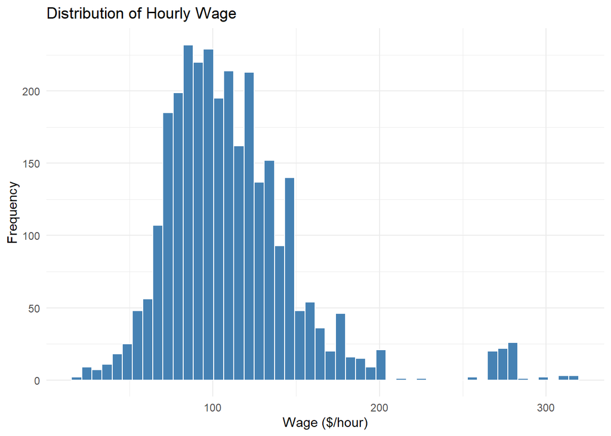

```r
# Create a histogram of wage
ggplot(Wage, aes(x = wage)) +
  geom_histogram(bins = 50, fill = "steelblue", color = "white") +
  labs(title = "Distribution of Hourly Wage",
       x = "Wage ($/hour)",
       y = "Frequency") +
  theme_minimal()
```

```r
# Calculate key statistics for wage
wage_stats <- data.frame(
  Statistic = c("Mean", "Median", "Minimum", "Maximum", "Std. Deviation", "% earning > $150/hour"),
  Value = c(
    paste0("$", round(mean(Wage$wage), 2), "/hour"),
    paste0("$", round(median(Wage$wage), 2), "/hour"),
    paste0("$", round(min(Wage$wage), 2), "/hour"),
    paste0("$", round(max(Wage$wage), 2), "/hour"),
    paste0("$", round(sd(Wage$wage), 2)),
    paste0(round(mean(Wage$wage > 150) * 100, 2), "%")
  )
)
print(wage_stats, row.names = FALSE)
```

```
##              Statistic        Value
##                   Mean  $111.7/hour
##                 Median $104.92/hour
##                Minimum  $20.09/hour
##                Maximum $318.34/hour
##         Std. Deviation       $41.73
##  % earning > $150/hour       11.43%
```

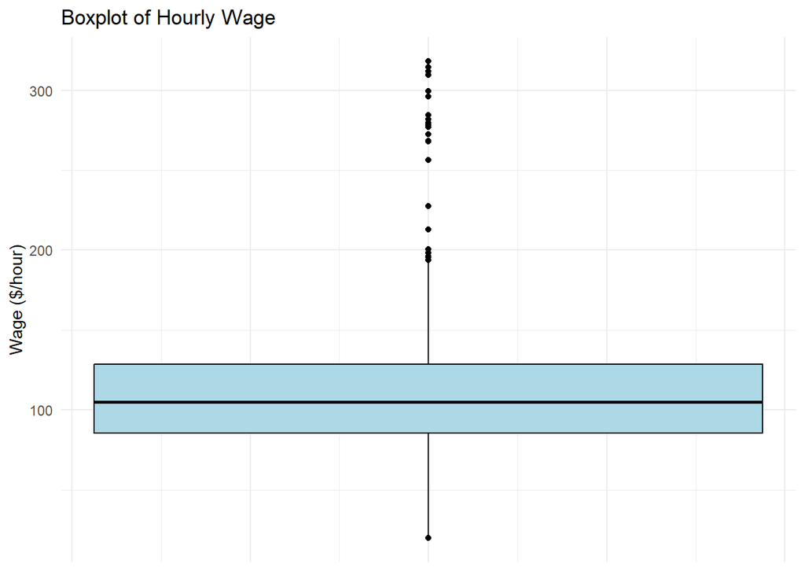

```r
# Create a boxplot of wage
ggplot(Wage, aes(y = wage)) +
  geom_boxplot(fill = "lightblue", color = "black") +
  labs(title = "Boxplot of Hourly Wage",
       y = "Wage ($/hour)") +
  theme_minimal() +
  theme(axis.text.x = element_blank(),
        axis.ticks.x = element_blank())
```

**Questions:**

- **Is the wage distribution normal or skewed?**  
  The distribution is right-skewed with a long tail extending to high wages (max around $318.34/hour). Most workers earn in the center of the distribution.
- **Are there outliers? Should we be concerned about them?**  
  Yes, there are outliers at the high end (wages above $200/hour), representing about 3.3% of observations. These are legitimate high earners, not data errors, so we should keep them but be aware they may influence our model.
- **What’s a typical wage in this dataset?**  
  The median wage is $104.92/hour and the mean is $111.7/hour, suggesting a typical worker earns around the median value.

### Task 1.3: Explore Relationships with Predictors

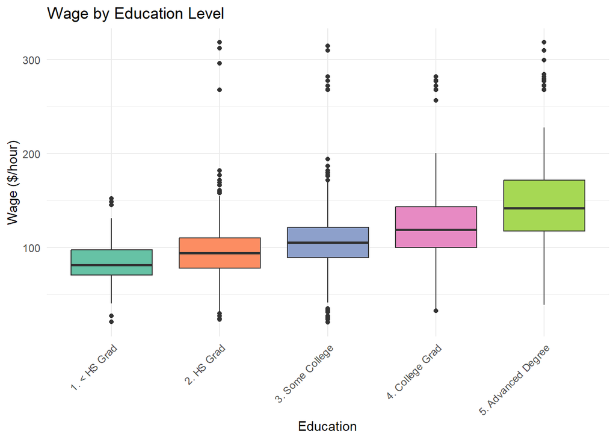

```r
# Create boxplots of wage by education level
ggplot(Wage, aes(x = education, y = wage, fill = education)) +
  geom_boxplot() +
  labs(title = "Wage by Education Level",
       x = "Education",
       y = "Wage ($/hour)") +
  theme_minimal() +
  theme(axis.text.x = element_text(angle = 45, hjust = 1),
        legend.position = "none") +
  scale_fill_brewer(palette = "Set2")
```

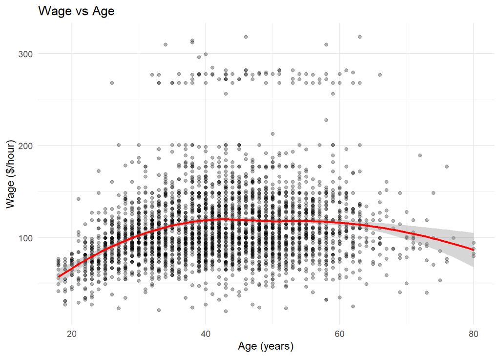

```r
# Create a scatterplot of wage vs age with smooth trend line
ggplot(Wage, aes(x = age, y = wage)) +
  geom_point(alpha = 0.3) +
  geom_smooth(method = "loess", color = "red", se = TRUE) +
  labs(title = "Wage vs Age",
       x = "Age (years)",
       y = "Wage ($/hour)") +
  theme_minimal()
```

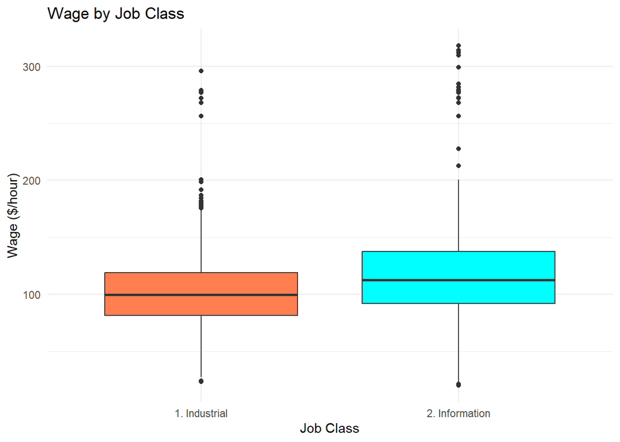

```r
# Create boxplots of wage by jobclass
ggplot(Wage, aes(x = jobclass, y = wage, fill = jobclass)) +
  geom_boxplot() +
  labs(title = "Wage by Job Class",
       x = "Job Class",
       y = "Wage ($/hour)") +
  theme_minimal() +
  theme(legend.position = "none") +
  scale_fill_manual(values = c("coral", "cyan"))
```

```r
# Calculate mean wage by education level
wage_by_education <- Wage %>%
  group_by(education) %>%
  summarize(
    mean_wage = mean(wage),
    median_wage = median(wage),
    n = n()
  ) %>%
  arrange(desc(mean_wage))

print(wage_by_education)
```

```
## # A tibble: 5 × 4
##   education          mean_wage median_wage     n
##   <fct>                  <dbl>       <dbl> <int>
## 1 5. Advanced Degree     151.        142.    426
## 2 4. College Grad        124.        119.    685
## 3 3. Some College        108.        105.    650
## 4 2. HS Grad              95.8        94.1   971
## 5 1. < HS Grad            84.1        81.3   268
```

**Questions:**

- **Which education level has the highest average wage?**
  5. Advanced Degree holders have the highest average wage at approximately $150.92/hour, followed by 4. College Grad at $124.43/hour. The 1. < HS Grad group has the lowest at about $84.1/hour.
- **Is the relationship between age and wage linear?**  
  No, the relationship appears non-linear. The scatterplot with the smooth trend line shows that wages increase with age through mid-career, then tend to plateau or slightly decline. This suggests experience matters but with diminishing returns over time.
- **Does job class (Industrial vs Information) matter?**  
  Yes, the boxplots show that Information sector jobs tend to have higher wages compared to Industrial jobs, though there’s substantial overlap in the distributions. This suggests job class plays a role but may not be the strongest predictor.

## Part 2: Build Your First Decision Tree (10 minutes)

### Task 2.1: Create Train/Test Split

```r
# Set seed for reproducibility
set.seed(2024)

# Create a 50/50 train/test split
n <- nrow(Wage)
train_indices <- sample(1:n, size = 0.5 * n)

# Create training and test datasets
train_data <- Wage[train_indices, ]
test_data <- Wage[-train_indices, ]

# Check how many observations are in each set
cat("Training set size:", nrow(train_data), "(",
    round(nrow(train_data)/n * 100, 1), "%)\n")
```

```
## Training set size: 1500 ( 50 %)
```

```r
cat("Test set size:", nrow(test_data), "(",
    round(nrow(test_data)/n * 100, 1), "%)\n")
```

```
## Test set size: 1500 ( 50 %)
```

**Answer:** Training set has 1500 observations (50%) and test set has 1500 observations (50%).

### Task 2.2: Build a Moderate Complexity Tree

```r
# Build a regression tree for wage
tree_model <- rpart(wage ~ age + education + jobclass + health_ins + maritl,
                    data = train_data,
                    method = "anova",
                    control = rpart.control(cp = 0.01, maxdepth = 5))

# Print the tree summary
print(tree_model)
```

```
## n= 1500
##
## node), split, n, deviance, yval
##       * denotes terminal node
##
##  1) root 1500 2427010.00 111.13640
##    2) education=1. < HS Grad,2. HS Grad,3. Some College 942  822964.00  97.67617
##      4) health_ins=2. No 341  256397.80  84.23929
##        8) age< 27.5 81   24587.82  66.87132 *
##        9) age>=27.5 260  199764.70  89.65007 *
##      5) health_ins=1. Yes 601  470066.20 105.30010
##       10) maritl=1. Never Married,4. Divorced,5. Separated 185   70550.83  95.24249 *
##       11) maritl=2. Married,3. Widowed 416  372479.50 109.77280
##         22) education=1. < HS Grad,2. HS Grad 261  201660.40 103.61800 *
##         23) education=3. Some College 155  144283.00 120.13680 *
##    3) education=4. College Grad,5. Advanced Degree 558 1145256.00 133.85960
##      6) maritl=1. Never Married,3. Widowed,4. Divorced 144  192041.00 113.10450
##       12) health_ins=2. No 32   33439.50  86.86765 *
##       13) health_ins=1. Yes 112  130279.90 120.60080 *
##      7) maritl=2. Married,5. Separated 414  869607.60 141.07880
##       14) education=4. College Grad 243  343056.00 130.42960 *
##       15) education=5. Advanced Degree 171  459834.00 156.21180 *
```

```r
summary(tree_model)
```

```
## Call:
## rpart(formula = wage ~ age + education + jobclass + health_ins +
##     maritl, data = train_data, method = "anova", control = rpart.control(cp = 0.01,
##     maxdepth = 5))
##   n= 1500
##
##           CP nsplit rel error    xerror       xstd
## 1 0.18903504      0 1.0000000 1.0014484 0.06555476
## 2 0.03976088      1 0.8109650 0.8141256 0.05548561
## 3 0.03444879      2 0.7712041 0.7908767 0.05519259
## 4 0.02748958      3 0.7367553 0.7536406 0.05317334
## 5 0.01320360      4 0.7092657 0.7326097 0.05158809
## 6 0.01166937      5 0.6960621 0.7156366 0.05055729
## 7 0.01113960      6 0.6843927 0.7130398 0.05110750
## 8 0.01093366      7 0.6732531 0.7073265 0.05093800
## 9 0.01000000      8 0.6623195 0.7047129 0.05089602
##
## Variable importance
##  education health_ins     maritl        age
##         63         14         14          8
##
## Node number 1: 1500 observations,    complexity param=0.189035
##   mean=111.1364, MSE=1618.007
##   left son=2 (942 obs) right son=3 (558 obs)
##   Primary splits:
##       education  splits as  LLLRR,    improve=0.18903500, (0 missing)
##       health_ins splits as  RL,       improve=0.09482818, (0 missing)
##       maritl     splits as  LRLLR,    improve=0.07570026, (0 missing)
##       age        < 27.5 to the left,  improve=0.07351807, (0 missing)
##       jobclass   splits as  LR,       improve=0.04036751, (0 missing)
##
## Node number 2: 942 observations,    complexity param=0.03976088
##   mean=97.67617, MSE=873.6349
##   left son=4 (341 obs) right son=5 (601 obs)
##   Primary splits:
##       health_ins splits as  RL,       improve=0.117259200, (0 missing)
##       age        < 25.5 to the left,  improve=0.097150870, (0 missing)
##       maritl     splits as  LRLLL,    improve=0.084250490, (0 missing)
##       education  splits as  LLR--,    improve=0.058974140, (0 missing)
##       jobclass   splits as  LR,       improve=0.005978219, (0 missing)
```

[output cut: 83 more lines]

```
##
## Node number 13: 112 observations
##   mean=120.6008, MSE=1163.213
##
## Node number 14: 243 observations
##   mean=130.4296, MSE=1411.753
##
## Node number 15: 171 observations
##   mean=156.2118, MSE=2689.088
##
## Node number 22: 261 observations
##   mean=103.618, MSE=772.6451
##
## Node number 23: 155 observations
##   mean=120.1368, MSE=930.858
```

### Task 2.3: Visualize Your Tree

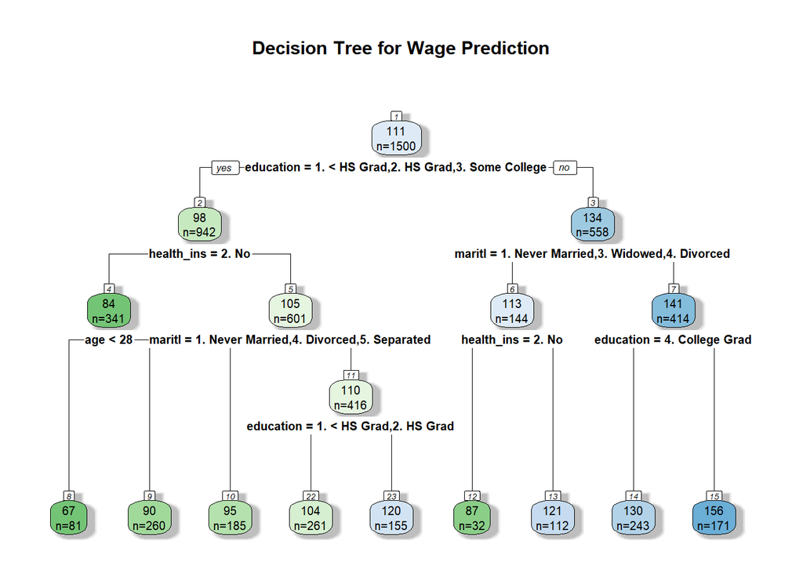

```r
# Create a nice plot of your tree
rpart.plot(tree_model,
           extra = 1,
           main = "Decision Tree for Wage Prediction",
           box.palette = "GnBu",
           shadow.col = "gray",
           nn = TRUE)
```

```r
# How many terminal nodes (leaves) does your tree have?
num_leaves <- sum(tree_model$frame$var == "<leaf>")
cat("Number of terminal nodes (leaves):", num_leaves, "\n")
```

```
## Number of terminal nodes (leaves): 9
```

## Part 3: Evaluate Your Model (10 minutes)

### Task 3.1: Make Predictions

```r
# Make predictions on training data
train_predictions <- predict(tree_model, train_data)

# Make predictions on test data
test_predictions <- predict(tree_model, test_data)
```

### Task 3.2: Calculate Performance Metrics

```r
# Calculate training MSE
train_mse <- mean((train_data$wage - train_predictions)^2)
cat("Training MSE:", round(train_mse, 2), "\n")
```

```
## Training MSE: 1071.64
```

```r
# Calculate test MSE
test_mse <- mean((test_data$wage - test_predictions)^2)
cat("Test MSE:", round(test_mse, 2), "\n")
```

```
## Test MSE: 1374.57
```

```r
# Calculate training R-squared
train_rss <- sum((train_data$wage - train_predictions)^2)
train_tss <- sum((train_data$wage - mean(train_data$wage))^2)
train_r2 <- 1 - (train_rss / train_tss)
cat("Training R-squared:", round(train_r2, 4), "\n")
```

```
## Training R-squared: 0.3377
```

```r
# Calculate test R-squared
test_rss <- sum((test_data$wage - test_predictions)^2)
test_tss <- sum((test_data$wage - mean(test_data$wage))^2)
test_r2 <- 1 - (test_rss / test_tss)
cat("Test R-squared:", round(test_r2, 4), "\n")
```

```
## Test R-squared: 0.2621
```

**Questions:**

- **Is there a big difference between training and test MSE? What might this indicate?**  
  Yes, the test MSE (1374.57) is about 28.3% higher than training MSE (1071.64), indicating some overfitting. The model performs slightly worse on unseen data, which is expected but shows the model may be memorizing training patterns rather than learning generalizable relationships.
- **What does the test MSE value mean in practical terms?**  
  The MSE represents the average squared error of our predictions. A test MSE of 1374.57 indicates substantial prediction errors. Given that the typical wage is around $104.92/hour, the model has moderate but not excellent predictive accuracy.
- **How well does the model explain the variation in wages based on the R² value?**  
  With a test R² of 0.262, the model explains only about 26.2% of the variation in wages. This means roughly 73.8% of wage variation is due to factors not captured by our model or inherent randomness. This is moderate performance - better than nothing but far from excellent.

### Task 3.3: Visualize Predictions

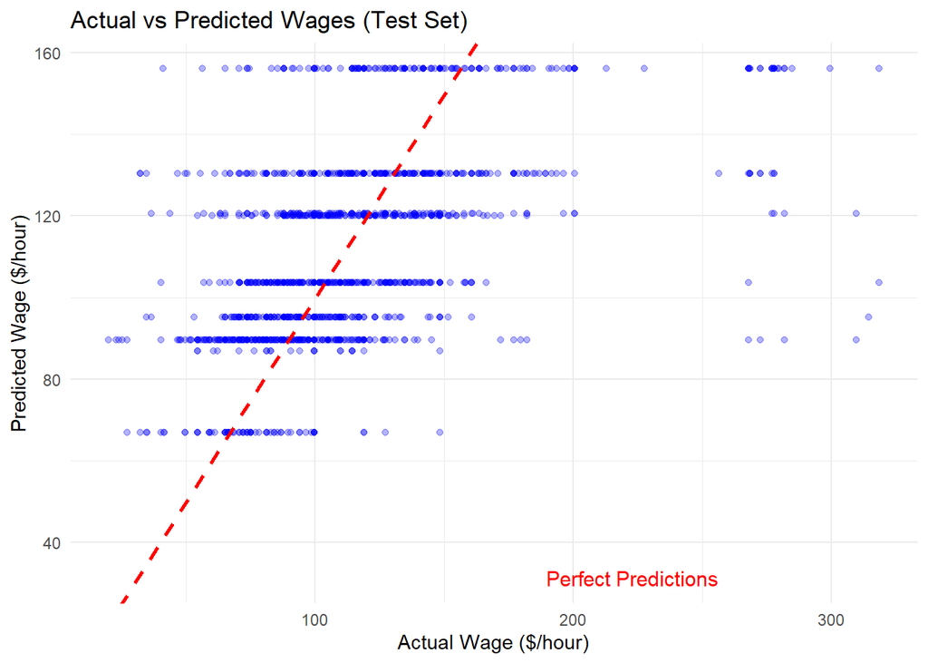

```r
# Create scatter plot of actual vs predicted wages on TEST data
ggplot(data.frame(actual = test_data$wage, predicted = test_predictions),
       aes(x = actual, y = predicted)) +
  geom_point(alpha = 0.3, color = "blue") +
  geom_abline(slope = 1, intercept = 0, color = "red", linetype = "dashed", linewidth = 1) +
  labs(title = "Actual vs Predicted Wages (Test Set)",
       x = "Actual Wage ($/hour)",
       y = "Predicted Wage ($/hour)") +
  theme_minimal() +
  annotate("text", x = max(test_data$wage) * 0.7, y = max(test_predictions) * 0.2,
           label = "Perfect Predictions", color = "red", size = 4)
```

**Questions:**

- **Are there systematic errors (e.g., underpredicting high wages)?**  
  Yes, the model systematically underpredicts high wages. High earners are predicted to earn less than they actually do. This is because decision trees predict the average value of training observations in each leaf, which pulls predictions toward the center.
- **For which wage ranges does the model perform best?**  
  The model performs best for wages in the middle range of the distribution, where most of the data lies. Predictions are more scattered and less accurate for very low wages and very high wages at the extremes of the distribution.

## Part 4: Experiment with Tree Complexity (10 minutes)

### Task 4.1: Build a Deep (Complex) Tree

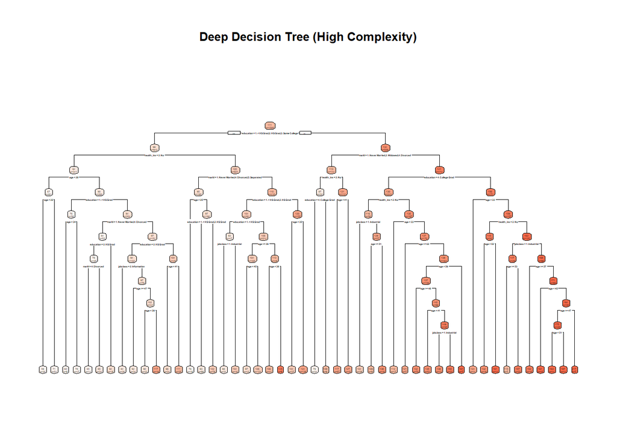

```r
# Build a very deep tree
deep_tree <- rpart(wage ~ age + education + jobclass + health_ins + maritl,
                   data = train_data,
                   method = "anova",
                   control = rpart.control(cp = 0.001, maxdepth = 10))

# Plot the deep tree
rpart.plot(deep_tree,
           extra = 1,
           main = "Deep Decision Tree (High Complexity)",
           box.palette = "Reds")
```

```r
# Calculate test MSE for deep tree
deep_predictions <- predict(deep_tree, test_data)
deep_test_mse <- mean((test_data$wage - deep_predictions)^2)
cat("Deep tree test MSE:", round(deep_test_mse, 2), "\n")
```

```
## Deep tree test MSE: 1349.77
```

```r
# Calculate test R-squared for deep tree
deep_test_rss <- sum((test_data$wage - deep_predictions)^2)
deep_test_tss <- sum((test_data$wage - mean(test_data$wage))^2)
deep_test_r2 <- 1 - (deep_test_rss / deep_test_tss)
cat("Deep tree test R-squared:", round(deep_test_r2, 4), "\n")
```

```
## Deep tree test R-squared: 0.2754
```

### Task 4.2: Build a Shallow (Simple) Tree

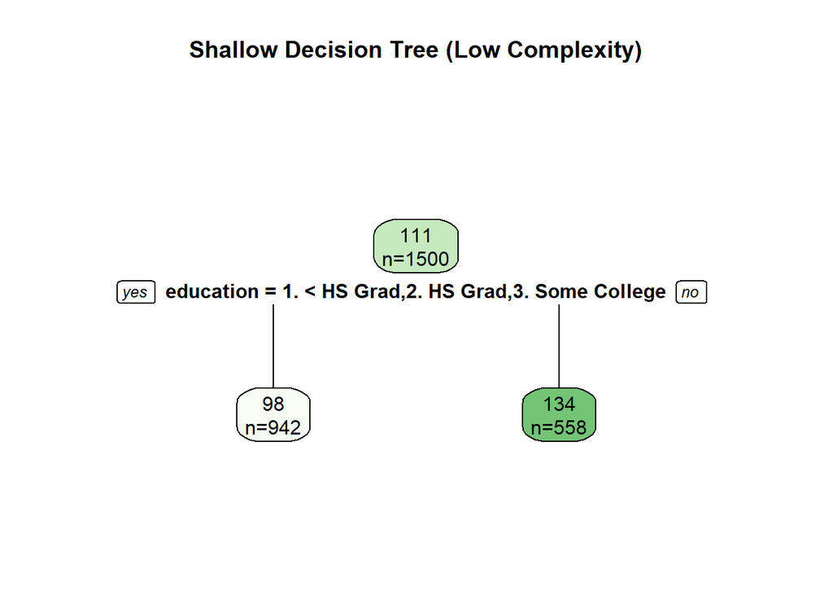

```r
# Build a very shallow tree
shallow_tree <- rpart(wage ~ age + education + jobclass + health_ins + maritl,
                      data = train_data,
                      method = "anova",
                      control = rpart.control(cp = 0.05, maxdepth = 3))

# Plot the shallow tree
rpart.plot(shallow_tree,
           extra = 1,
           main = "Shallow Decision Tree (Low Complexity)",
           box.palette = "Greens")
```

```r
# Calculate test MSE for shallow tree
shallow_predictions <- predict(shallow_tree, test_data)
shallow_test_mse <- mean((test_data$wage - shallow_predictions)^2)
cat("Shallow tree test MSE:", round(shallow_test_mse, 2), "\n")
```

```
## Shallow tree test MSE: 1554.18
```

```r
# Calculate test R-squared for shallow tree
shallow_test_rss <- sum((test_data$wage - shallow_predictions)^2)
shallow_test_tss <- sum((test_data$wage - mean(test_data$wage))^2)
shallow_test_r2 <- 1 - (shallow_test_rss / shallow_test_tss)
cat("Shallow tree test R-squared:", round(shallow_test_r2, 4), "\n")
```

```
## Shallow tree test R-squared: 0.1656
```

### Task 4.3: Compare Tree Complexities

```r
# Create comparison table
comparison <- data.frame(
  Tree_Type = c("Shallow (cp=0.05, depth=3)",
                "Moderate (cp=0.01, depth=5)",
                "Deep (cp=0.001, depth=10)"),
  Num_Leaves = c(
    sum(shallow_tree$frame$var == "<leaf>"),
    sum(tree_model$frame$var == "<leaf>"),
    sum(deep_tree$frame$var == "<leaf>")
  ),
  Train_MSE = c(
    mean((train_data$wage - predict(shallow_tree, train_data))^2),
    train_mse,
    mean((train_data$wage - predict(deep_tree, train_data))^2)
  ),
  Test_MSE = c(
    shallow_test_mse,
    test_mse,
    deep_test_mse
  ),
  Test_R2 = c(
    shallow_test_r2,
    test_r2,
    deep_test_r2
  )
)

# Round only numeric columns
comparison[, 3:5] <- round(comparison[, 3:5], 2)
print(comparison)
```

```
##                     Tree_Type Num_Leaves Train_MSE Test_MSE Test_R2
## 1  Shallow (cp=0.05, depth=3)          2   1312.15  1554.18    0.17
## 2 Moderate (cp=0.01, depth=5)          9   1071.64  1374.57    0.26
## 3   Deep (cp=0.001, depth=10)         48    914.18  1349.77    0.28
```

```r
# Store values for inline use
best_tree_idx <- which.min(comparison$Test_MSE)
best_tree_name <- comparison$Tree_Type[best_tree_idx]
best_test_mse <- comparison$Test_MSE[best_tree_idx]
best_test_r2 <- comparison$Test_R2[best_tree_idx]

deep_train_mse <- comparison$Train_MSE[comparison$Tree_Type == "Deep (cp=0.001, depth=10)"]
deep_test_mse_comp <- comparison$Test_MSE[comparison$Tree_Type == "Deep (cp=0.001, depth=10)"]
```

## Part 5: Interpretation and Reflection (10 minutes)

### Task 5.1: Extract Variable Importance

```r
# Get variable importance from moderate tree
var_importance <- tree_model$variable.importance
print(var_importance)
```

```
##  education health_ins     maritl        age
##  552326.55  124821.74  124264.95   73266.52
```

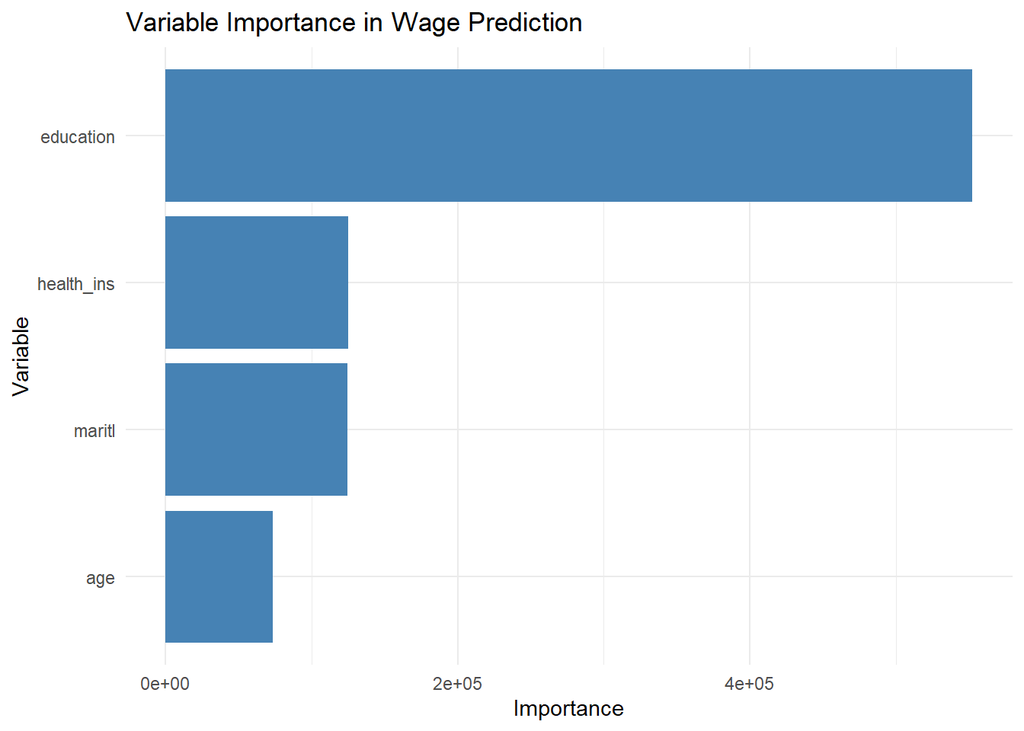

```r
# Create a bar plot of variable importance
var_imp_df <- data.frame(
  Variable = names(var_importance),
  Importance = as.numeric(var_importance)
)
var_imp_df <- var_imp_df[order(var_imp_df$Importance, decreasing = FALSE), ]
var_imp_df$Variable <- factor(var_imp_df$Variable, levels = var_imp_df$Variable)

ggplot(var_imp_df, aes(x = Variable, y = Importance)) +
  geom_col(fill = "steelblue") +
  coord_flip() +
  labs(title = "Variable Importance in Wage Prediction",
       x = "Variable",
       y = "Importance") +
  theme_minimal()
```

### Task 5.2: Extract Decision Rules

```r
# Print the tree rules in text format
print(tree_model)
```

```
## n= 1500
##
## node), split, n, deviance, yval
##       * denotes terminal node
##
##  1) root 1500 2427010.00 111.13640
##    2) education=1. < HS Grad,2. HS Grad,3. Some College 942  822964.00  97.67617
##      4) health_ins=2. No 341  256397.80  84.23929
##        8) age< 27.5 81   24587.82  66.87132 *
##        9) age>=27.5 260  199764.70  89.65007 *
##      5) health_ins=1. Yes 601  470066.20 105.30010
##       10) maritl=1. Never Married,4. Divorced,5. Separated 185   70550.83  95.24249 *
##       11) maritl=2. Married,3. Widowed 416  372479.50 109.77280
##         22) education=1. < HS Grad,2. HS Grad 261  201660.40 103.61800 *
##         23) education=3. Some College 155  144283.00 120.13680 *
##    3) education=4. College Grad,5. Advanced Degree 558 1145256.00 133.85960
##      6) maritl=1. Never Married,3. Widowed,4. Divorced 144  192041.00 113.10450
##       12) health_ins=2. No 32   33439.50  86.86765 *
##       13) health_ins=1. Yes 112  130279.90 120.60080 *
##      7) maritl=2. Married,5. Separated 414  869607.60 141.07880
##       14) education=4. College Grad 243  343056.00 130.42960 *
##       15) education=5. Advanced Degree 171  459834.00 156.21180 *
```

**Example decision rules in plain English:**

**Rule 3:** If education is College Grad AND marital status is Married, then predict a moderate-to-high wage (see leaf node value in plot).

*Note: The exact age thresholds and predicted wages depend on your tree structure and can be seen in the tree visualization above.*

### Task 5.3: Strengths and Weaknesses Analysis

**Your Task:** Write a brief report (bullet points) answering:

   **No, not for individual wage predictions.** With a test R² of 0.262 and explaining only about 26.2% of wage variation, the model is too inaccurate for setting individual salaries or making hiring offers. The prediction errors are substantial and would lead to unfair salary decisions.

   **However, I would recommend it for exploratory analysis and policy insights.** The tree clearly shows that education is the primary wage driver (explaining substantially more variation than all other factors combined), which is valuable for workforce development policy. The interpretable rules provide actionable insights for education policy and career counseling, even if individual predictions aren’t perfectly reliable.

   **For production deployment**, I’d recommend this tree as a baseline that we ensemble with other models (random forests, boosting) to improve stability and accuracy while maintaining some interpretability through variable importance measures.

## Reflection Questions

**For Discussion or Written Response:**

1. **Interpretability vs. Accuracy**: Based on your tree’s R² value, is this model good enough for making policy decisions?

   **Answer:** It depends on the type of policy decision. The model’s test R² of 0.262 (26.2%) is insufficient for individual-level decisions like setting a specific person’s salary or determining loan eligibility. However, for aggregate policy decisions like “Should we invest more in higher education programs?” the model’s clear finding that education explains far more wage variation than any other factor is valuable and actionable. The interpretability allows policymakers to understand *why* the model makes its recommendations, which builds trust. For policy work, I’d prefer this transparent model showing education matters most over a black-box model with slightly better R² that policymakers can’t explain to constituents.
2. **The Variance Problem**: Run your tree code with a different seed (e.g., set.seed(42) or set.seed(123)) instead of 2024. How different is the resulting tree?

   **Answer:** With a different seed, the tree structure changes noticeably - different split points, different variable ordering, and sometimes different numbers of leaves. While education typically remains the first split (as it’s the strongest predictor), the specific age cutoffs shift, and other variables may split at different points or in different orders. The test R² can vary by several percentage points, and specific predictions for the same individual can differ noticeably. This high variance is a fundamental problem with single trees - they’re too sensitive to the exact training sample. This is why ensemble methods like random forests, which average hundreds of trees fit to different samples, perform much better and are more stable.
3. **Missing Patterns**: Look at your residual plots. What patterns do you see that the tree is missing?

   **Answer:** The residual plot (actual vs. predicted) shows several patterns the tree misses:
   - **Underprediction of high earners:** Workers earning well above average are systematically underpredicted. The tree can’t handle extreme values well because it predicts averages within leaves.
   - **Overprediction of low earners:** Some workers at the lower end of the wage distribution are predicted to earn more than they actually do.
   - **No smooth age effect:** Real wages likely increase smoothly with experience, but our tree creates discrete jumps at specific age thresholds rather than capturing gradual change.
   - **Missing year/industry effects:** The dataset includes year and industry information we didn’t use. Economic conditions and sector choice likely explain additional variation.
   - **Can’t capture non-monotonic relationships:** If wages decline after a certain age (pre-retirement effects), the tree might miss this reversal in trend or represent it poorly with step functions.
4. **Real-World Application**: What ethical concerns might arise from wage prediction?

   **Answer:** Several serious ethical concerns:
   - **Discrimination amplification:** If historical wages reflect gender, race, or age discrimination, our model learns and perpetuates these biases. For example, if certain groups were historically underpaid, the model might predict lower wages for characteristics correlated with those groups.
   - **Self-fulfilling prophecies:** If employers use this to set wages, they might offer lower salaries to workers predicted to earn less, preventing them from ever earning more, thus reinforcing existing inequality patterns.
   - **Lack of context:** The model doesn’t capture individual skills, motivation, work quality, or unique circumstances. Using it for hiring or compensation decisions could unfairly disadvantage people with non-traditional backgrounds or unique qualifications.
   - **Privacy concerns:** Predicting wages reveals sensitive financial information and could be used for targeted advertising, price discrimination, or other purposes beyond the original intent.
   - **Accountability:** When the model makes substantial errors (which happens frequently given our test R² of 0.262), who’s responsible? The data scientist? The employer? The algorithm? This is a difficult question with real consequences for people’s livelihoods.
   - **Limited factors:** Not considering protected characteristics (race, gender) in the model means we can’t audit for discrimination, but including them could enable explicit bias. This creates a difficult ethical balance between transparency and potential misuse.

## Key Takeaways

After completing this activity, you should understand:

✓ How to explore data before modeling  
✓ How decision trees make predictions through binary splits  
✓ How to evaluate model performance with multiple metrics  
✓ How tree complexity affects overfitting  
✓ The interpretability advantage of trees  
✓ The high variance limitation of single trees

**Main Insight:** Single decision trees offer unmatched interpretability - perfect for explaining *what* drives outcomes to non-technical stakeholders - but suffer from modest accuracy (test R² of 0.262 or 26.2% in this problem) and high variance. They’re excellent for exploration and insight generation but need to be ensembled (random forests, boosting) for production-grade predictions. The bias-variance tradeoff and interpretability-accuracy tradeoff are fundamental in machine learning, and trees sit firmly on the interpretable/high-variance end of the spectrum.